# Investigation Overview

I wanted to take a look at the features contained in the dataset that affects the trips durations.

## Trip Duration destribution

Plotting the distribution of trips according to their durations

The trip duration distributoin is skewed steeply to the right, with mode equals over 100,000 for durations between 0 and 10 mins.And the plot shows a mean of 11 mins.

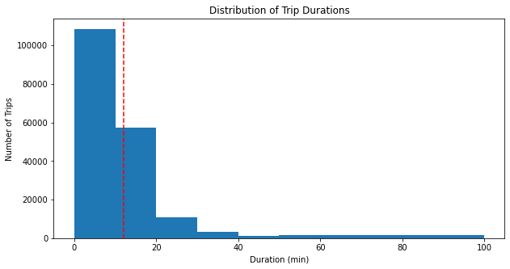

```python
plt.figure(figsize=[10, 5])
plt.hist(data = df, x = 'duration_minute',bins=[0, 10, 20, 30, 40, 50, 100])
plt.title('Distribution of Trip Durations')
plt.xlabel('Duration (min)')
plt.ylabel('Number of Trips')
plt.axvline(df['duration_minute'].mean(), color='r', linestyle='--')
plt.show()
```

## Distribution of users age

Plotting the distribution of users age

The high percent of users have ages between 25-35 years old

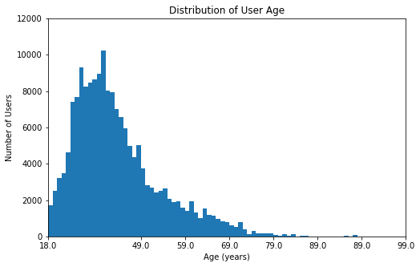

```python
binsize = 1
bins = np.arange(0, df['member_birth_year'].astype(float).max()+binsize, binsize)
minBirthYear = df['member_birth_year'].astype(float).min()
maxBirthYear =df['member_birth_year'].astype(float).max()
plt.figure(figsize=[8, 5])
plt.hist(data = df.dropna(), x = 'member_birth_year', bins = bins)
plt.axis([minBirthYear, maxBirthYear, 0, 12000])
plt.xticks([minBirthYear, minBirthYear+10, minBirthYear+20, minBirthYear+30, minBirthYear+40, minBirthYear+50, minBirthYear+60, maxBirthYear], [(2019-minBirthYear), (2019-minBirthYear-10), (2019-minBirthYear-10), (2019-minBirthYear-20), (2019-minBirthYear-30), (2019-minBirthYear-40), (2019-minBirthYear-50), (2019-maxBirthYear)])
plt.gca().invert_xaxis()
plt.title('Distribution of User Age')
plt.xlabel('Age (years)')
plt.ylabel('Number of Users')
plt.show()
```

# The relationship between age and trip durations

The plot shall view the users age with the corresponding trip durations

Obviously higher durations are for users with ages near 30 years old

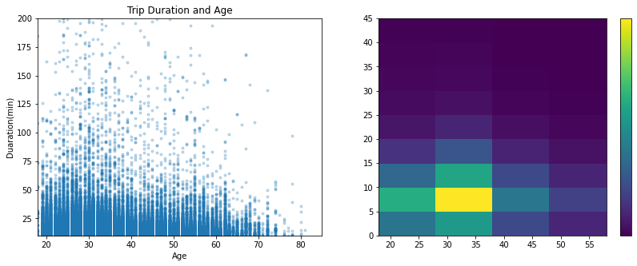

```python
plt.figure(figsize=[14,5])

plt.subplot(1, 2, 1)
plt.scatter((2019 - df['member_birth_year']), df['duration_minute'], alpha = 0.25, marker = '.' )
plt.axis([18, 85, 10, 200])
plt.title('Trip Duration and Age')
plt.xlabel('Age')
plt.ylabel('Duaration(min)')

plt.subplot(1, 2, 2)
bins_y = np.arange(0, 50, 5)
bins_x = np.arange(18, 60, 10)
plt.hist2d((2019 - df['member_birth_year']), df['duration_minute'],
           bins = [bins_x, bins_y])
plt.colorbar(ticks=[0, 10, 20, 50]);
plt.show()
```

## Bivariate relation between duration and gender

There are alot of female using long ride trips than male

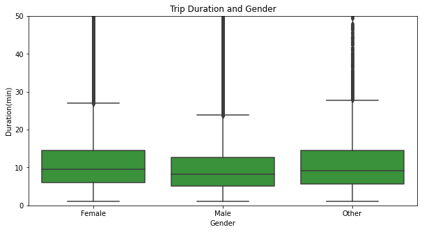

```python
plt.figure(figsize = [10, 5])
base_color = sb.color_palette()[2]
sb.boxplot(data = df, x = 'member_gender', y = 'duration_minute', color = base_color)
plt.ylim([0, 50])
plt.title('Trip Duration and Gender')
plt.xlabel('Gender')
plt.ylabel('Duration(min)')
plt.show()
```

## Hourly Usage during Weekdays for Male and Female

There are no different usage patterns for the two genders of riders . Many trips concentrated around 7-10am and 17-19 pm on work days when used for work commute Other than the different usage goals, it may also have to do with the traffic situation around these rush hours in the area.

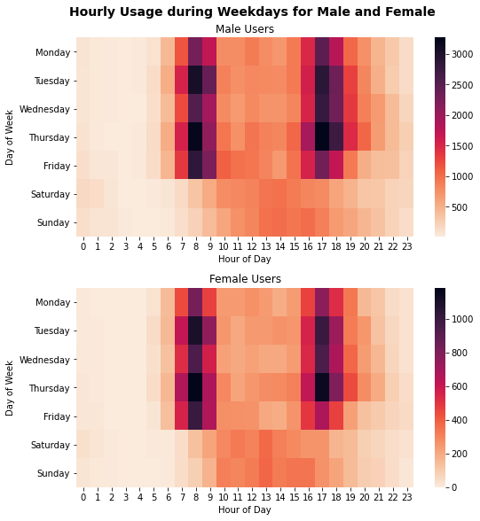

```python
plt.figure(figsize=[8, 8]);

plt.subplot(2, 1, 1)
male = df.query('member_gender == "Male"')
ct_counts = male.groupby(['start_dayofweek', 'start_hourofday']).size()
ct_counts = ct_counts.reset_index(name='count')
ct_counts = ct_counts.pivot(index='start_dayofweek', columns='start_hourofday', values='count')
sb.heatmap(ct_counts, cmap='rocket_r');
plt.title('Male Users', loc='center');
plt.xlabel('Hour of Day');
plt.ylabel('Day of Week');
plt.tight_layout();

plt.subplot(2, 1, 2)
female = df.query('member_gender == "Female"')
st_counts = female.groupby(['start_dayofweek', 'start_hourofday']).size()
st_counts = st_counts.reset_index(name='count')
st_counts = st_counts.pivot(index='start_dayofweek', columns='start_hourofday', values='count')
sb.heatmap(st_counts, cmap='rocket_r');
plt.title('Female Users', loc='center');
plt.xlabel('Hour of Day');
plt.ylabel('Day of Week');
plt.tight_layout();
plt.suptitle('Hourly Usage during Weekdays for Male and Female', fontsize=14, fontweight='semibold', y=1.015);
```

## User gender and their weekly usage

The plot is showing that the majority of trips are done during the weekdays and the most users gender is male, so we can coclude that users take rides for commuting, as the number of rides decrease in weekends.

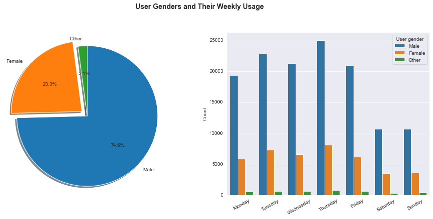

```python
plt.figure(figsize=[16, 6]);
base_color = sb.color_palette('colorblind')[3];
sb.set_style('darkgrid');

plt.subplot(1, 2, 1);
sorted_vals = df.dropna().member_gender.value_counts()/df.dropna().shape[0];
plt.pie(sorted_vals, explode=[0, 0.1, 0], labels=sorted_vals.index, startangle=90, counterclock=False, autopct='%1.1f%%', shadow=True);
plt.axis('square');

plt.subplot(1, 2, 2);
ax = sb.countplot(data=df, x='start_dayofweek', hue='member_gender', hue_order=sorted_vals.index);
ax.legend(title='User gender');
plt.xticks(rotation=30);
plt.xlabel('');
plt.ylabel('Count');
plt.suptitle('User Genders and Their Weekly Usage', fontsize=14, fontweight='semibold', y=1.015);
```

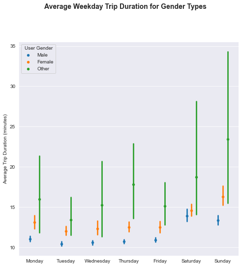

```python
plt.figure(figsize=[8, 8]);
ax = sb.pointplot(data=df, x='start_dayofweek', y='duration_minute', hue='member_gender', dodge=0.3, markers='.', linestyles="", hue_order=sorted_vals.index);
ax.legend(title='User Gender');
plt.xlabel('');
plt.ylabel('Average Trip Duration (minutes)');
plt.suptitle('Average Weekday Trip Duration for Gender Types', fontsize=14, fontweight='semibold', y=1.015);
```